# Roll Call data analysis

Author

Aneta Miniberger

## Setup

### Načítání balíků

```r
library(readr)
library(tidyr)
library(dplyr)
library(ggplot2)
library(stringr)
library(ggplot2)
library(runjags)
```

### Načítání dat

```r
osoby <- read.table(
  "osoby.unl",
  sep = "|",
  header = FALSE,
  na.strings = "",
  quote = "",
  stringsAsFactors = FALSE,
  fileEncoding = "Windows-1250",
  fill = TRUE
)

osoby <- osoby |>
  rename(
    id_osoba = V1,
    prijmeni = V3,
    jmeno = V4,
    sex = V7,
    ) |> select(
    id_osoba, prijmeni, jmeno, sex
  )

poslanec <- read.table(
  "poslanec.unl",
  sep = "|",
  header = FALSE,
  na.strings = "",
  quote = "",
  stringsAsFactors = FALSE,
  fileEncoding = "Windows-1250",
  fill = TRUE
)

poslanec <- poslanec |>
  rename(
    id_poslanec = V1,
    id_osoba = V2
  ) |>
  select(id_poslanec, id_osoba)

strany <- read.table(
  "osoba_extra.unl",
  sep = "|",
  header = FALSE,
  na.strings = "",
  quote = "",
  stringsAsFactors = FALSE,
  fileEncoding = "Windows-1250",
  fill = TRUE
)

strany <- strany |>
  rename(
  id_osoba = V1,
  strana = V5
) |> select(
  id_osoba, strana
)

osoby <- osoby |>
  full_join(strany, by = "id_osoba")

osoby <- osoby[!duplicated(osoby), ]

poslanec <- poslanec |>
  inner_join(osoby, by = "id_osoba")

Y <- read.table(
  "hl2021h1.unl",
  sep = "|",
  header = FALSE,
  na.strings = "",
  quote = "",
  stringsAsFactors = FALSE,
  fileEncoding = "Windows-1252",
  fill = TRUE
)

hlasovani <- read.table(
  "hl2021s.unl",
  sep = "|",
  header = FALSE,
  na.strings = "",
  quote = "",
  stringsAsFactors = FALSE,
  fileEncoding = "Windows-1250",
  fill = TRUE
)

hlasovani <- hlasovani |>
  rename(
    id_hlasovani = V1,
    schuze = V3,
    c_hl = V4,
    datum = V6,
    cas = V7,
    pro = V8,
    proti = V9,
    zdrzel = V10,
    nehlasoval = V11,
    prihlaseno = V12,
    druh_hl = V14,
    vysledek = V15,
    nazev = V16,
    nazev_kr = V17
  )|>
  select(id_hlasovani, schuze,c_hl, datum, cas, pro,
        proti,nehlasoval,prihlaseno,druh_hl,vysledek,
        nazev, nazev_kr)

Y <- Y |>
  rename(
    id_poslanec = V1,
    id_hlasovani = V2,
    vysledek = V3
  ) |>
  select(
    id_poslanec, id_hlasovani, vysledek) |>
  mutate(
    vysledek = factor(vysledek, levels = c("A", "B","@","K"),
                labels = c("ano", "ne", "neprihlášen", "nehlasoval"))
  )

Y <- Y |>
  left_join(poslanec |> select(id_poslanec, id_osoba, jmeno, prijmeni), by = "id_poslanec")

Y$jmeno_kom <- paste(Y$jmeno, Y$prijmeni)
```

[figure not shown]

Design databáze

## Analýza

### Úvod

- Politologický cíl: **najít abstraktní ideologický postoj pro každého poslance,** který vysvětluje rozdíly v hlasování

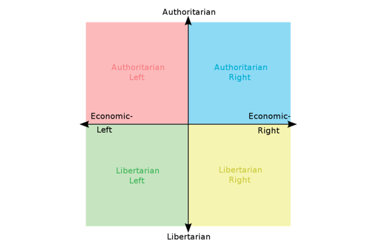

- Ale ideologie je **latentní** (nepozorovaná), pozorovat ale můžeme výsledky tzv. “*roll-call*” hlasování
- Matice hlasování: 1 = pro, 0 = proti, NA = zdržel se, chyběl
- Zdroj dat: [Data Poslanecké sněmovny](https://www.psp.cz/sqw/hp.sqw?k=1300)

### Zavedení proměnných a předpokladů

Pracujme na $d-$rozměrném ideologickém prostoru. Každý zákonodárce $i$, $i = 1, \dots, N$ má ideální bod $\mathbf{x}_i \in \mathbb{R}^d$. Každý návrh zákona $j$, $j = 1, \dots, M$ má:

- $\boldsymbol{\zeta}_j \in \mathbb{R}^d$: pozice **přijmutí** zákona v daném ideologickém prostoru
- $\boldsymbol{\psi}_j \in \mathbb{R}^d$: pozice **odmítnutí** zákona v daném ideologickém prostoru.

Předpokládáme, že zákonodárci mají užitkové funkce

$$U_i(\boldsymbol{\zeta}_j) = -\|\mathbf{x}_i - \boldsymbol{\zeta}_j\|^2 + \eta_{ij}, \quad U_i(\boldsymbol{\psi}_j) = -\|\mathbf{x}_i - \boldsymbol{\psi}_j\|^2 + \nu_{ij},$$

kde $\eta_{ij}$ a $\nu_{ij}$ jsou náhodné chyby, u kterých předpokládáme normální rozdělení, nezávislost, nulovou střední hodnotu a $Var( \eta_{ij} - \nu_{ij}) = \sigma_j^2$. Rozhodnutí $i$-tého zákonodárce u $j$-tého zákonu značíme $y_{ij}$. Platí $y_{ij} = 1$, pokud zákonodárce hlasoval pro a $y_{ij} = 0$, pokud hlasoval proti.

### Probitový model

Teoreticky se zákonodárce rozhodne volit pro to, co mu přinse větší užitek, tj.
$$\begin{align} P(y_{ij} = 1) &= P(U_i(\boldsymbol{\zeta}_j) > U_i(\boldsymbol{\psi}_j)) \\ &= P\left( \nu_{ij} - \eta_{ij} < x_i - \psi_j^2 - x_i - \zeta_j^2 \right) \\ &= P\left( \nu_{ij} - \eta_{ij} < 2(\zeta_j - \psi_j)x_i + \psi_j^2 - \zeta_j^2 \right) \\ &= \Phi(\beta_j x_i - \alpha_j) \end{align}$$

Což je zobecněný lineární model s probitovým linkem pro vektor regresorů $x_i$. (Později budeme pracovat s logisickým modelem). Zavedeme následující proměnné:

- $y^* = \beta_j x_i - \alpha_j + \varepsilon_{ij}$,
- $m \times d$ matici $\boldsymbol{B}$, jejíž sloupce jsou vektory $\beta_j$,
- $n \times d$ matici $X$, jejíž řádky jsou vektory $x_i$,
- $n \times m$ matici $Y$, která je tvořena prvky $y_{ij}$.

### Identifikace

Bez omezení je model **neidentifikovaný**, můžeme dostat stejné výsledky pro rotaci či posun v dimenzi latentních proměnných. Proto musíme zafixovat ideální body pro tolik politiků, aby jednoznačně určili matici $X$. Pro vybrané politiky použijeme spike prior:  
$\mathbf{x}_i \sim N(c, \nu I)$, kde $\nu$ je velmi malé číslo a $c$ je konstanta.

### Volba apriorních rozdělení

- $\mathbf{x}_i \sim N(0, I)$,
- $\boldsymbol{\beta}_j \sim N(0, \kappa I), \alpha_j \sim N(0, \kappa I)$, kde $\kappa$ je velké číslo.

### Iterační krok t

1. **Vzorkování** $(y^*_{ij}|y_{ij}, x_i^{t-1}, \beta_j^{t-1}, \alpha_j^{t-1})$:

- Pokud $y_{ij} = 1$, vzorkujeme $y^*_{ij}$ z useknutého $N(\mu_{ij}, 1)$ na $(0, \infty)$,
- Pokud $y_{ij} = 0$, tak z useknutého $N(\mu_{ij}, 1)$ na $(-\infty, 0)$,
- kde $\mu_{ij} = x_i^{t-1} \beta_{j}^{t-1} - \alpha_{j}^{t-1}$
2. **Vzorkování** $(\beta_{j}^{t}, \alpha_{j}^{t}|y^*_{ij}, x_i^{t-1})$
   - Regrese: $y^*_{ij} = x_i^{t-1} \beta_{j}^{t} - \alpha_{j}^{t} + \varepsilon$
3. **Vzorkování** $(x_i^{t}|y^*_{ij}, \beta_j^{t}, \alpha_j^{t})$:
   - “Opačná” regrese: $y^*_{ij} + \alpha_{j}^{t} = x_i^{t} \beta_{j}^{t} + \varepsilon$

Jak se tento proces změní když budeme pracovat s logistickou regresí?
$$\Pr(y_{ij} = 1) = \text{logit}^{-1}(x_i \beta_{j} - \alpha_{j})$$

## JAGS

### Důchodová reforma

```r
Yjags <- Y |> mutate(
  vysledek_bin = case_when(
    vysledek == "ano" ~ 1,
    vysledek == "ne" ~ 0,
    TRUE ~ NA_real_
  )
)

Yjags <- Yjags |>
 select(id_hlasovani, jmeno_kom, vysledek_bin) |>
 pivot_wider(names_from = "id_hlasovani", values_from = "vysledek_bin")

Kotvy <- c("Marek Benda", "Alena Schillerová")
indKotvy <- which(Yjags$jmeno_kom %in% Kotvy)

Yjags <- Yjags %>%
  mutate(row_id = row_number()) %>%
  arrange(jmeno_kom %in% Kotvy %>% desc()) %>%
  select(-row_id)

vybrani_pos <- c("Karel Havlíček", # ano
                 "Patrik Nacher", # ano
                 "Tomio Okamura", # spd
                 "Hyato Okamura", # kdu
                 "Vít Rakušan", # stan
                 "Olga Richterová", #pirati
                 "Bohuslav Svoboda", #ods
                 "Marek Výborný", #kdu
                 "Ivan Bartoš", # pirati
                 "Petr Liška" # stan
                 )

strany <- c("ANO",
            "ANO",
            "SPD",
            "STAN",
            "PIR",
            "ODS",
            "KDU",
            "PIR",
            "STAN")
ind_vybrani <- which(Yjags$jmeno_kom %in% vybrani_pos)

Yjags <- Yjags |>
  filter(
    jmeno_kom %in% vybrani_pos | jmeno_kom %in% Kotvy
  )

id_duchod <- hlasovani |>
  filter(schuze == 55) |>
  select(id_hlasovani)

id_duchod <- id_duchod$id_hlasovani

Yjags <- Yjags |>
  select(jmeno_kom, as.character(id_duchod))

mat <- as.matrix(Yjags |> select(-jmeno_kom))
dimnames(mat) <- NULL
```

```r
jags.model <-
"model {
  for(i in 1:N){
    for(j in 1:M){
      logit(pi[i,j]) <- x[i] * beta1[j] - beta2[j]
      y[i,j] ~ dbern(pi[i,j])
    }
  }

  for(i in 3:N){
    x[i] ~ dnorm(0, 0.01)
  }
  x[1] <- -1 #alena schillerova jako -1
  x[2] <- 1 #marek benda jako 1

  for(j in 1:M){
    beta1[j] ~ dnorm(0, 0.04)
    beta2[j] ~ dnorm(0, 0.04)
  }
}
"
```

```r
mat_sampled <- mat
result <- run.jags(
  model = jags.model,
  data = list(
    N = nrow(mat_sampled), # pocet poslancu
    M = ncol(mat_sampled), # pocet hlasovani
    y = mat_sampled #hlasovani poslancu v matici
  ),
  monitor = c("x"), # monitoruji pouze zajmovou promennou
  n.chains = 1,
  burnin = 1000,
  sample = 5000,
  adapt = 1000,
  confidence = 0.95,
  thin = 1,
  summarise = FALSE,
  silent.jags = TRUE
)

MCMC <- result$mcmc |> as.matrix(iters = TRUE, chains = TRUE) |> as.data.frame()
sim <- MCMC |> pivot_longer(-c("CHAIN", "ITER"))
sim <- as.data.frame(sim)
```

JAGS simulace trvají dlouho - pro zjednodušení práce s tímto reportem tedy analytujeme výsledky, které byly uložené z předchozích běhů.

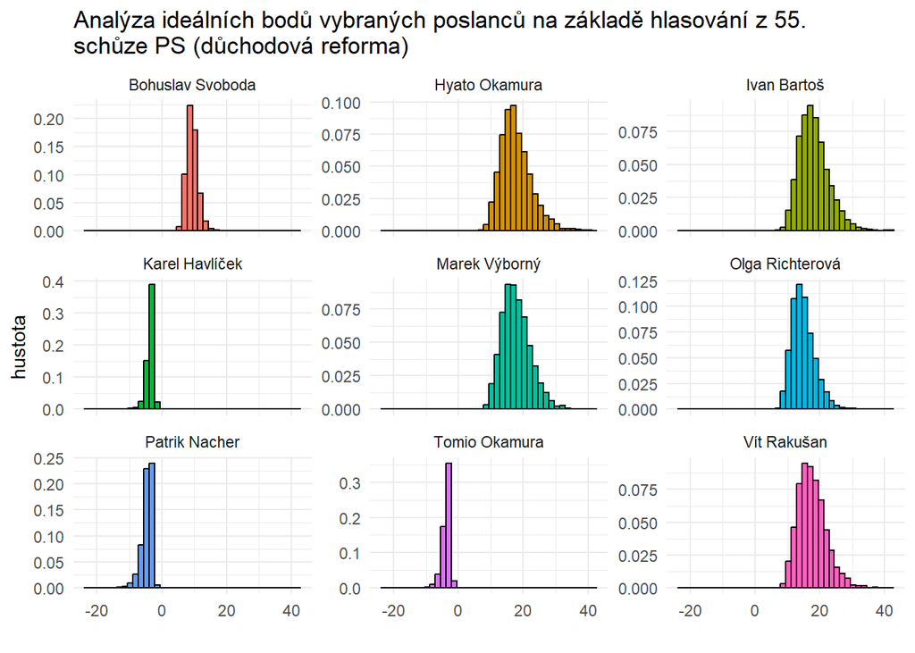

```r
sim1 <- readRDS("sim1.rds")
sim <- sim1

sim1 |>
  filter(name != "x[1]" & name != "x[2]") |>
  ggplot(aes(x = value, fill = jmeno, y = after_stat(density))) +
  geom_histogram(bins = 40,color = "black", linewidth = 0.5) +
  labs(x = "", y = "hustota") +
  facet_wrap("jmeno", scales = "free_y") +
  guides(fill = FALSE) +
  theme_minimal()+
  ggtitle(str_wrap("Analýza ideálních bodů vybraných poslanců na základě hlasování z 55. schůze PS (důchodová reforma)", width = 70))
```

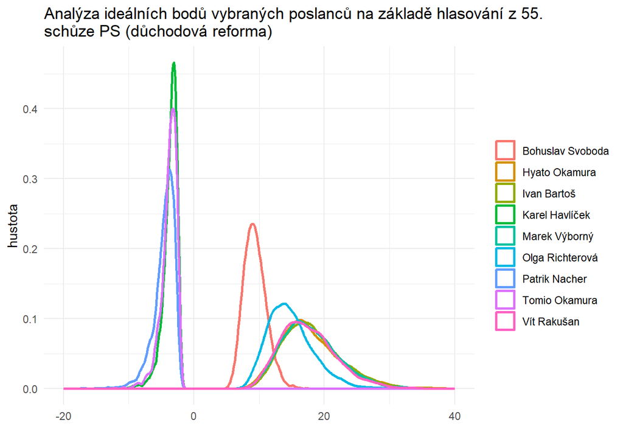

```r
sim1 |>
 filter(name != "x[1]" & name != "x[2]") |>
  ggplot(aes(x = value, color = jmeno)) +
  geom_density(linewidth = 1.0) +
  labs(x = "", y = "hustota", color = "") +
  theme_minimal() +
  xlim(-20, 40) +
  ggtitle(str_wrap("Analýza ideálních bodů vybraných poslanců na základě hlasování z 55. schůze PS (důchodová reforma)", width = 70))
```

```r
stat <- sim1 |>
 filter(name != "x[1]" & name != "x[2]") |>
  group_by(jmeno) |>
  summarise(
      MAP = bayestestR::map_estimate(value)$MAP_Estimate,
      mean = mean(value),
      sd = sd(value),
      CI = t(quantile(value, probs = c(0.025, 0.975))),
      ET = t(HDInterval::hdi(value, credMass = 0.95))
    )

stat |> kableExtra::kable()
```

[output not shown]

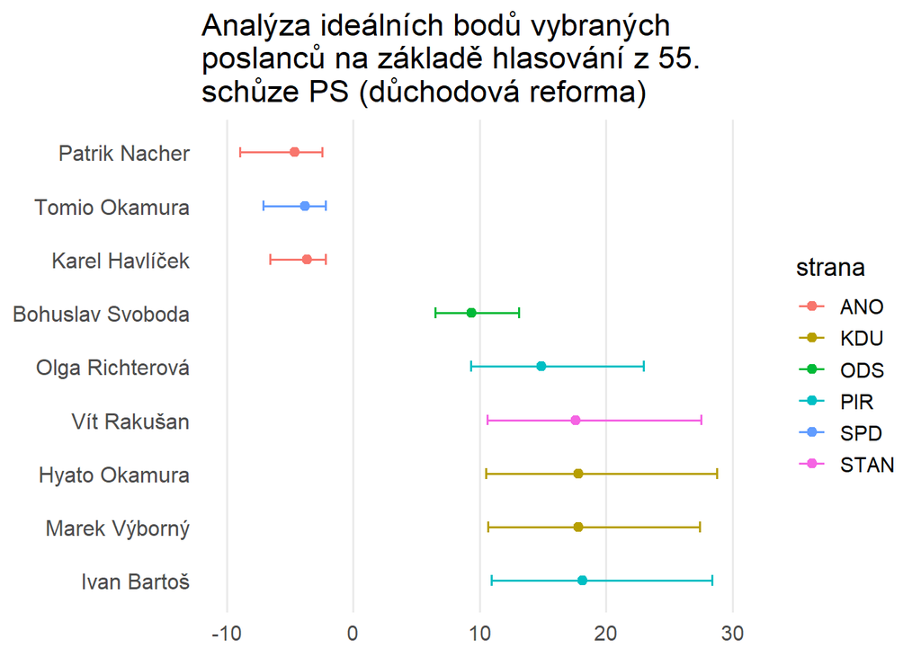

```r
comp <- data.frame(
  name = stat$jmeno,
  strana = c("ODS", "KDU", "PIR", "ANO", "KDU", "PIR", "ANO", "SPD", "STAN"),
  estimate = stat$mean,
  lower = stat$CI[, 1],
  upper = stat$CI[, 2]
)
comp <- comp |>
  arrange(estimate |> desc()) |>
  mutate(name = factor(name, levels = name))

ggplot(comp, aes(x = estimate, y = name, color = strana)) +
  geom_point(size = 2) +
  geom_errorbarh(aes(xmin = lower, xmax = upper), height = 0.2) +
  scale_x_continuous(
    limits = c(-10, 30),
    breaks = seq(-10, 30, 10),
    name = NULL
  ) +
  labs(y = NULL) +
  theme_minimal(base_size = 14) +
  theme(
    axis.title.y = element_blank(),
    axis.text.y = element_text(size = 12),
    panel.grid.major.y = element_blank(),
    panel.grid.minor = element_blank(),
  )+  ggtitle(str_wrap("Analýza ideálních bodů vybraných poslanců na základě hlasování z 55. schůze PS (důchodová reforma)", width = 40))
```

### Manželství pro všechny

```r
Y <- read.table(
  "hl2021h2.unl",
  sep = "|",
  header = FALSE,
  na.strings = "",
  quote = "",
  stringsAsFactors = FALSE,
  fileEncoding = "Windows-1252",
  fill = TRUE
)

Y <- Y |>
  rename(
    id_poslanec = V1,
    id_hlasovani = V2,
    vysledek = V3
  ) |>
  select(
    id_poslanec, id_hlasovani, vysledek) |>
  mutate(
    vysledek = factor(vysledek, levels = c("A", "B","@","K"),
                labels = c("ano", "ne", "neprihlášen", "nehlasoval"))
  )

Y <- Y |>
  left_join(poslanec |> select(id_poslanec, id_osoba, jmeno, prijmeni), by = "id_poslanec")

Y$jmeno_kom <- paste(Y$jmeno, Y$prijmeni)

Yjags <- Y |> mutate(
  vysledek_bin = case_when(
    vysledek == "ano" ~ 1,
    vysledek == "ne" ~ 0,
    TRUE ~ NA_real_
  )
)

Yjags <- Yjags |>
 select(id_hlasovani, jmeno_kom, vysledek_bin) |>
 pivot_wider(names_from = "id_hlasovani", values_from = "vysledek_bin")


Kotvy <- c("Josef Bernard", "Pavel Bělobrádek")
indKotvy <- which(Yjags$jmeno_kom %in% Kotvy)

Yjags <- Yjags %>%
  mutate(row_id = row_number()) %>%
  arrange(jmeno_kom %in% Kotvy %>% desc()) %>%
  select(-row_id)

vybrani_pos <- c("Andrej Babiš", # ano
                  "Ivan Bartoš", # pirati
                  "Marek Benda", # ods
                 "Eva Decroix", #ods
                 "Martin Exner", # stan
                  "Petr Gazdík", # stan
                  "Nina Nováková", #kdu
                 "Tomio Okamura", # spd
                 "Hyato Okamura" # kdu
                 )

strany <- c("ANO",
            "PIR",
            "ODS",
            "ODS",
            "STAN",
            "STAN",
            "KDU",
            "SPD",
            "KDU")


ind_vybrani <- which(Yjags$jmeno_kom %in% vybrani_pos)
Yjags <- Yjags |>
  filter(
    jmeno_kom %in% vybrani_pos | jmeno_kom %in% Kotvy
  )


id_manzeltsvi <- hlasovani |>
  filter(schuze == 94) |>
  select(id_hlasovani)

id_manzeltsvi <- id_manzeltsvi$id_hlasovani

Yjags <- Yjags |>
  select(jmeno_kom, as.character(id_manzeltsvi))


mat <- as.matrix(Yjags |> select(-jmeno_kom))
dimnames(mat) <- NULL
```

```r
jags.model <-
"model {
  for(i in 1:N){
    for(j in 1:M){
      logit(pi[i,j]) <- x[i] * beta1[j] - beta2[j]
      y[i,j] ~ dbern(pi[i,j])
    }
  }

  for(i in 3:N){
    x[i] ~ dnorm(0, 0.01)
  }
  x[1] <- 1 # Josef Bernard jako 1
  x[2] <- -1 # Pavel Bělobrádek jako -1

  for(j in 1:M){
    beta1[j] ~ dnorm(0, 0.04)
    beta2[j] ~ dnorm(0, 0.04)
  }
}
"
```

```r
result <- run.jags(
  model = jags.model,
  data = list(
    N = nrow(mat), # pocet poslancu
    M = ncol(mat),# pocet hlasovani
    y = mat #hlasovani poslancu v matici
  ),
  monitor = c("x"), # monitoruji pouze zajmovou promennou
  n.chains = 1,
  burnin = 1000,
  sample = 5000,
  adapt = 1000,
  confidence = 0.95,
  thin = 1,
  summarise = FALSE,
  silent.jags = TRUE
)
MCMC <- result$mcmc |> as.matrix(iters = TRUE, chains = TRUE) |> as.data.frame()
sim <- MCMC |> pivot_longer(-c("CHAIN", "ITER"))
sim <- as.data.frame(sim)
saveRDS(sim, "sim2.rds")
```

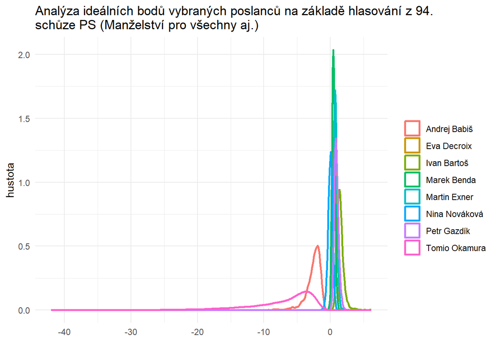

```r
sim2 <- readRDS("sim2.rds")
sim <- sim2

custom_labels <- c(Kotvy, vybrani_pos)
levels <- unique(sim$name[str_detect(sim$name, "x")])
names(custom_labels) <- levels
names(custom_labels)[11] <- "x[11]"
jmenax <- data.frame(jmeno = custom_labels, x = names(custom_labels))
sim <- left_join(sim, jmenax, join_by(name == x))

sim |>
 filter(name != "x[1]" & name != "x[2]") |>
  ggplot(aes(x = value, color = jmeno)) +
  geom_density(linewidth = 1.0) +
  labs(x = "", y = "hustota", color = "") +
  theme_minimal() +
  ggtitle(str_wrap("Analýza ideálních bodů vybraných poslanců na základě hlasování z 94. schůze PS (Manželství pro všechny aj.)", width = 70))
```

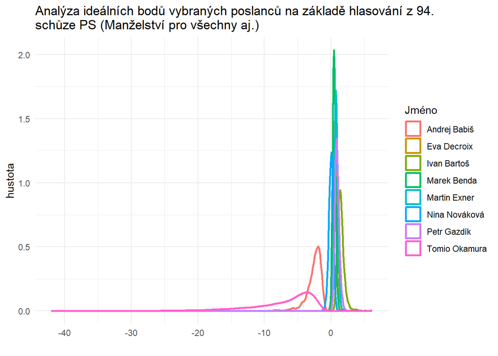

```r
sim |>
 filter(name != "x[1]" & name != "x[2]") |>
  ggplot(aes(x = value, color = jmeno)) +
  geom_density(linewidth = 1.0) +
  labs(x = "", y = "hustota", color = "Jméno") +
  theme_minimal() +
  ggtitle(str_wrap("Analýza ideálních bodů vybraných poslanců na základě hlasování z 94. schůze PS (Manželství pro všechny aj.)", width = 70))
```

```r
stat <- sim |>
 filter(name != "x[1]" & name != "x[2]") |>
  group_by(jmeno) |>
  summarise(
      MAP = bayestestR::map_estimate(value)$MAP_Estimate,
      mean = mean(value),
      sd = sd(value),
      CI.lwr = t(quantile(value, probs = 0.025)),
      CI.upr = t(quantile(value, probs = 0.975)),
      ET.lwr = t(HDInterval::hdi(value, credMass = 0.95))[, 1],
      ET.upr = t(HDInterval::hdi(value, credMass = 0.95))[, 2]
    )

stat |> kableExtra::kable()
```

| jmeno | MAP | mean | sd | CI.lwr | CI.upr | ET.lwr | ET.upr |
| --- | --- | --- | --- | --- | --- | --- | --- |
| Andrej Babiš | -1.8716739 | -2.5828900 | 1.1858812 | -5.75870904 | -1.1938797 | -4.7420387 | -0.8787845 |
| Eva Decroix | 0.6287991 | 0.6587755 | 0.2759165 | 0.16559748 | 1.2421325 | 0.1177133 | 1.1831340 |
| Ivan Bartoš | 1.3590441 | 1.4801664 | 0.5455154 | 0.70469796 | 2.7075028 | 0.6038058 | 2.4725676 |
| Marek Benda | 0.4386218 | 0.4592329 | 0.2223517 | 0.05148331 | 0.9168414 | 0.0377424 | 0.9025651 |
| Martin Exner | 0.7180344 | 0.7731867 | 0.2579211 | 0.31298821 | 1.3168505 | 0.2624643 | 1.2586059 |
| Nina Nováková | 0.0344923 | -0.0099764 | 0.3236458 | -0.69273872 | 0.5815951 | -0.6741871 | 0.5912018 |
| Petr Gazdík | 0.7947897 | 0.9120591 | 0.3262436 | 0.36367296 | 1.6609834 | 0.3563845 | 1.6292741 |
| Tomio Okamura | -3.4996332 | -7.2341406 | 5.0424602 | -20.89518836 | -1.9804303 | -17.6440772 | -1.4842427 |

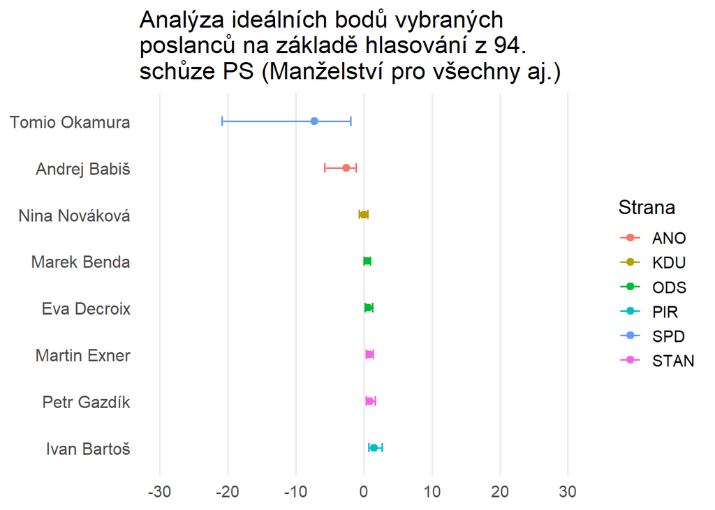

```r
comp <- data.frame(
  name = stat$jmeno,
  strana = c("ANO", "ODS", "PIR","ODS", "STAN","KDU","STAN", "SPD"),
  estimate = stat$mean,
  lower = stat$CI.lwr,
  upper = stat$CI.upr
)
comp <- comp |>
  arrange(estimate |> desc()) |>
  mutate(name = factor(name, levels = name))

ggplot(comp, aes(x = estimate, y = name, color = strana)) +
  geom_point(size = 2) +
  geom_errorbarh(aes(xmin = lower, xmax = upper), height = 0.2) +
  scale_x_continuous(
    limits = c(-30, 30),
    breaks = seq(-30, 30, 10),
    name = NULL
  ) +
  labs(y = NULL, color = "Strana") +
  theme_minimal(base_size = 14) +
  theme(
    axis.title.y = element_blank(),
    axis.text.y = element_text(size = 12),
    panel.grid.major.y = element_blank(),
    panel.grid.minor = element_blank(),
  ) +
    ggtitle(str_wrap("Analýza ideálních bodů vybraných poslanců na základě hlasování z 94. schůze PS (Manželství pro všechny aj.)", width = 40))
```